# Hard Work 3 Part 2

```r
library(car)
```

## Instructions

1. Study Sections 3.9-3.11 of Chapter 3: “Diagnostics and Remedial Measures.”
2. Attempt and submit at least {27} Hard Work Points by Saturday at 11:59 PM.  
   Over {37} gets you {+1} Final Exam Point.

## Reading Points {18} Possible

### Section 3.9 {7}{ 7 / 7 }

### Section 3.10 {4}{ 4 / 4 }

### Section 3.11 {7}{ 7 / 7 }

## Theory Points {7} Possible

### Exercise 3.20 {3}{ 3 / 3 }

If the error terms in a regression model are independent $N(0,\sigma^2)$, what can be said about the error terms after the transformation $X'=1/X$ is used? If the situation the same after the transformation $Y'=1/Y$ is used?

Considering that a transformation on X will only change the distances between each X it is logical to say that the independence of the error terms will not be altered. In the model the error terms are not in any way determined by X.

However, with a transformation on Y, the shape of the distribution can change drastically. This will alter the independence of the error terms.

### Exercise 3.22 {4}{ 4 / 4 }

Using (A.70), (A.41) and (A.42), show that $E \{ MSPE \} = \sigma^2$ for normal error regression model (2.1)

The stated references above are shown below.

(A.70)
$$\frac{(n-1)s^2}{\sigma^2} \sim \chi^2_{n-1}$$

(A.41)
$$\chi^2(\nu) = z^2_1+z_2^2+...+z^2_\nu \ \ \ \ \ \text{where the} \ z_i \ \text{are independent}$$

(A.42)
$$E \{ \chi^2(\nu) \}=\nu$$
Proof:

Consider the following
$$E \{ MSPE \}$$
By definition $MSPE=SSPE/(n-c)$ so the above expression becomes,
$$E \Big\{ \frac{SSPE}{n-c} \Big\}$$

Constants can be moved out of the expectation function and by definition SSPE can be expressed as the following,
$$\frac{1}{n-c}E \Big\{ \sum_{j=1}^c \sum_{i=1}^{n_j} (Y_{ij} - \bar{Y_j})^2 \Big\}$$

Using the fact that $s^2 = \sum (Y_i - \bar{Y})/(n-1)$, where $(n-1)$ is the degrees of freedom of $Y$, the above expression becomes,
$$\frac{1}{n-c} E \Big\{ \sum_{j=1}^c(n_j-1)s_j^2 \Big\}$$

Next multiplying the above equation by a factor of 1, $\sigma^2/ \sigma^2$ it becomes,
$$\frac{\sigma^2}{n-c} E \Big\{ \frac{\sum_{j=1}^c(n_j-1)s_j^2}{\sigma^2} \Big\}$$

Using (A.70) we can change the argument of the expectation into a sum of chi-squares.
$$\frac{\sigma^2}{n-c} E \Big\{ \sum_{j=1}^c \chi^2(n_j-1) \Big\}$$

The exprectation can be moved within the sum.
$$\frac{\sigma^2}{n-c} \sum_{j=1}^c E \{ \chi^2(n_j-1) \}$$

Now using (A.42) we can express the above equation as the following
$$\frac{\sigma^2}{n-c} \sum_{j=1}^c (n_j-1)$$

Distributing the sum
$$\frac{\sigma^2}{n-c} \sum_{j=1}^c n_j - \sum_{j=1}^c 1$$

By definition $\sum_{j=1}^c n_j = n$ so the above becomes,
$$\frac{\sigma^2}{n-c} (n - c) \\$$

After simplifying
$$E \{ MSPE \} = \sigma^2$$

## Application Points {17} Possible

[Data Files](http://www.stat.ufl.edu/~rrandles/sta4210/Rclassnotes/data/textdatasets/index.html)

### Problem 3.16 {6}{ 6 / 6 }

```r
# Load the Data:
p3.15 <- read.table("http://www.stat.ufl.edu/~rrandles/sta4210/Rclassnotes/data/textdatasets/KutnerData/Chapter%20%203%20Data%20Sets/CH03PR15.txt")

# Rewrite the column names to be "Y" and "X" to match the textbook:
colnames(p3.15) <- c("Y","X")

p3.15.lm <- lm(Y~X, data=p3.15)
```

1. Prepare a scatter plot of the data. what transformations of $Y$ might you try, using the prototype patterns in Figure 3.15 to achieve constant variance and linearity?

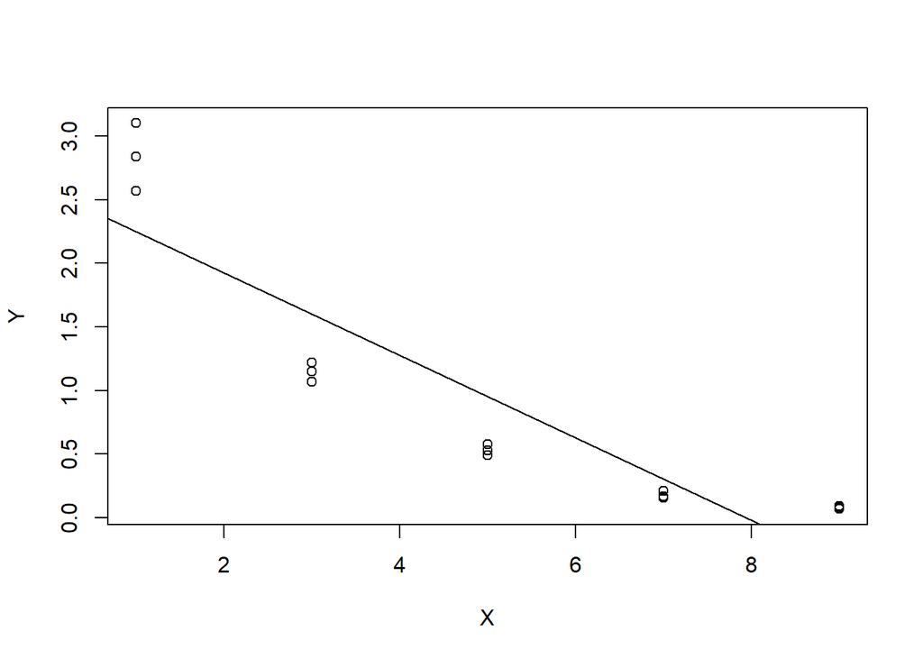

```r
plot(Y ~ X, data=p3.15)
abline(p3.15.lm)
```

based on the figure I would try $Y'=log_{10}Y$.

2. Use the Box-Cox procedure and standardization (3.36) to find an appropriate power transformation. Evaluate SSE for $\lambda = -.2, -.1, 0, .1, .2$. What transformation of $Y$ is suggested?

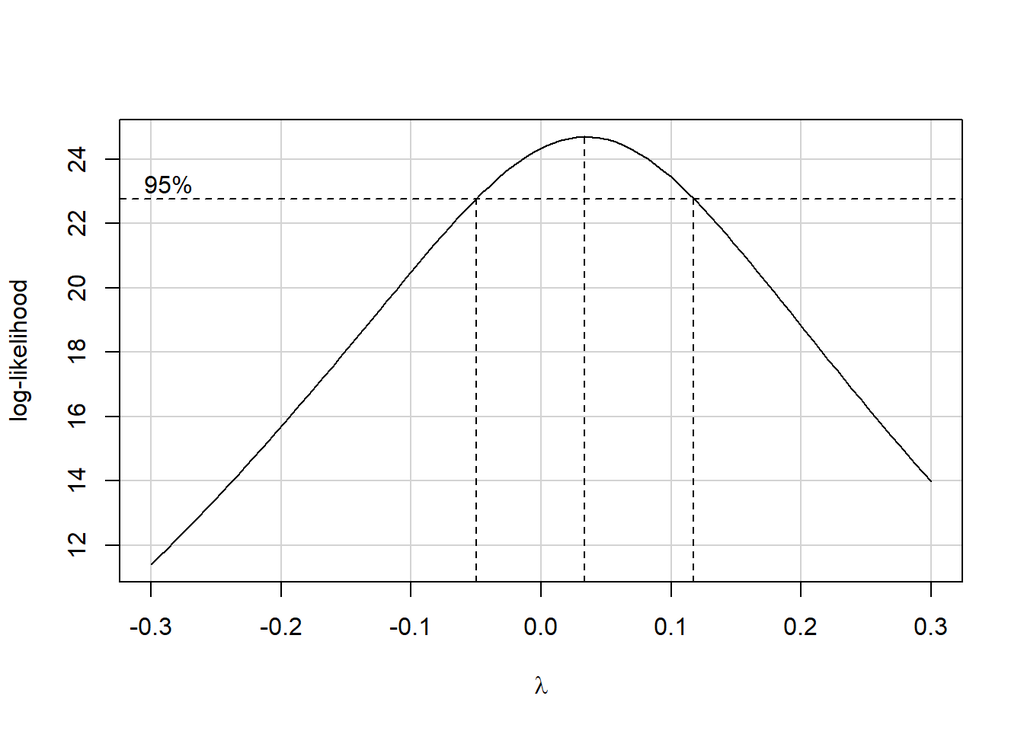

```r
boxCox(p3.15.lm, lambda=seq(-.3,.3,.05))
```

The best lambda seems to be $\lambda=0$.

SSE for lambda = -.2

```r
K2 <- (prod(p3.15$Y))^(1/15)
K1 <- 1/(-.2*K2^(-.2-1))
p3.15$W <- K1*((p3.15$Y^-.2)-1)
l1lm <- lm(W~X, data=p3.15)
sum((p3.15$W - l1lm$fitted.values)^2)
```

```
## [1] 0.1235305
```

SSE for lambda = -.1

```r
K1 <- 1/(-.1*K2^(-.1-1))
p3.15$W <- K1*((p3.15$Y^-.1)-1)
l1lm <- lm(W~X, data=p3.15)
sum((p3.15$W - l1lm$fitted.values)^2)
```

```
## [1] 0.06505067
```

SSE for lambda = 0

```r
p3.15$W <- K2*(log(p3.15$Y))
l1lm <- lm(W~X, data=p3.15)
sum((p3.15$W - l1lm$fitted.values)^2)
```

```
## [1] 0.03897303
```

SSE for lambda = .1

```r
K1 <- 1/(.1*K2^(.1-1))
p3.15$W <- K1*((p3.15$Y^.1)-1)
l1lm <- lm(W~X, data=p3.15)
sum((p3.15$W - l1lm$fitted.values)^2)
```

```
## [1] 0.04396062
```

SSE for lambda = .2

```r
K1 <- 1/(.2*K2^(.2-1))
p3.15$W <- K1*((p3.15$Y^.2)-1)
l1lm <- lm(W~X, data=p3.15)
sum((l1lm$residual)^2)
```

```
## [1] 0.08131793
```

```r
sum((p3.15$W - l1lm$fitted.values)^2)
```

```
## [1] 0.08131793
```

3. Use the transformation $Y' = log_{10}Y$ and obtain the estimated linear regression function for the transformed data.

```r
p3.15$Ynew <- log10(p3.15$Y)

p3.15.lm <- lm(Ynew ~ X, data=p3.15)
```

$log_{10}\hat{Y} = .655 -.1954X$

4. Plot the estimated regression line and the transformed data. Does the regression line appear to be a good fit to the transformed data?

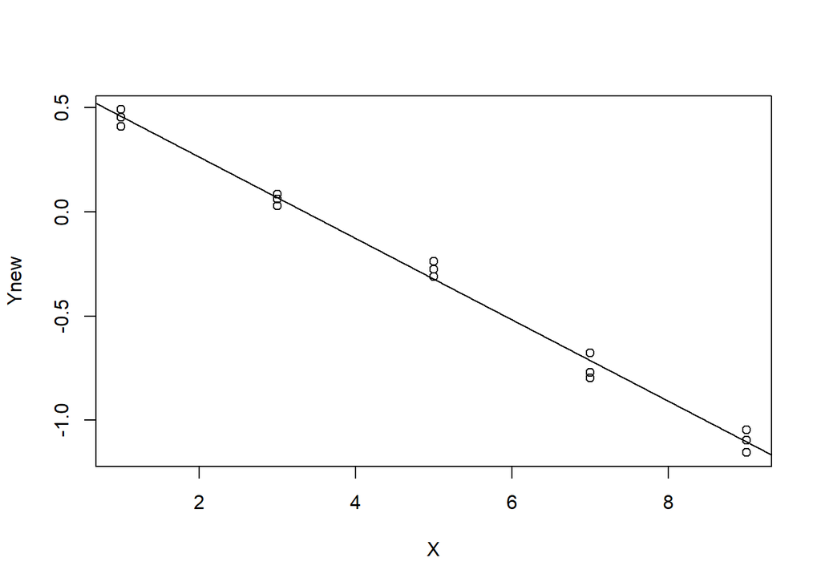

```r
plot(Ynew~X,data=p3.15)
b<-p3.15.lm$coefficients
abline(p3.15.lm)
```

If we plot the new estimated regression curve regression curve on the transformed data it does appear to be a good fit.

We can also plot the curve on the original data.

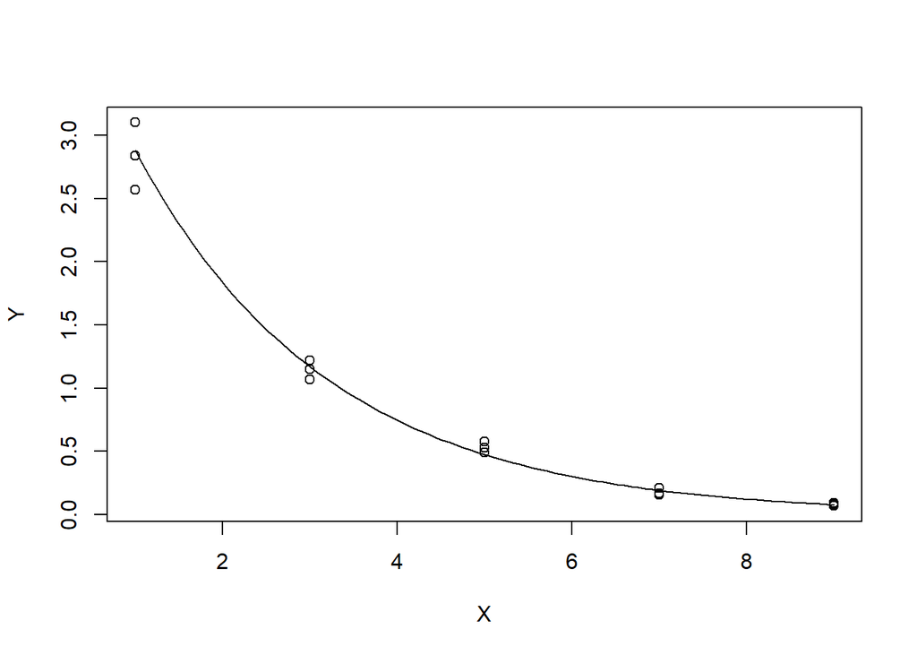

```r
plot(Y~X,data=p3.15)
curve(10^(b[1] + b[2]*x), add=TRUE)
```

5. Obtain the residuals and plot them against the fitted values. Also prepare a normal probability plot. What do your plots show?

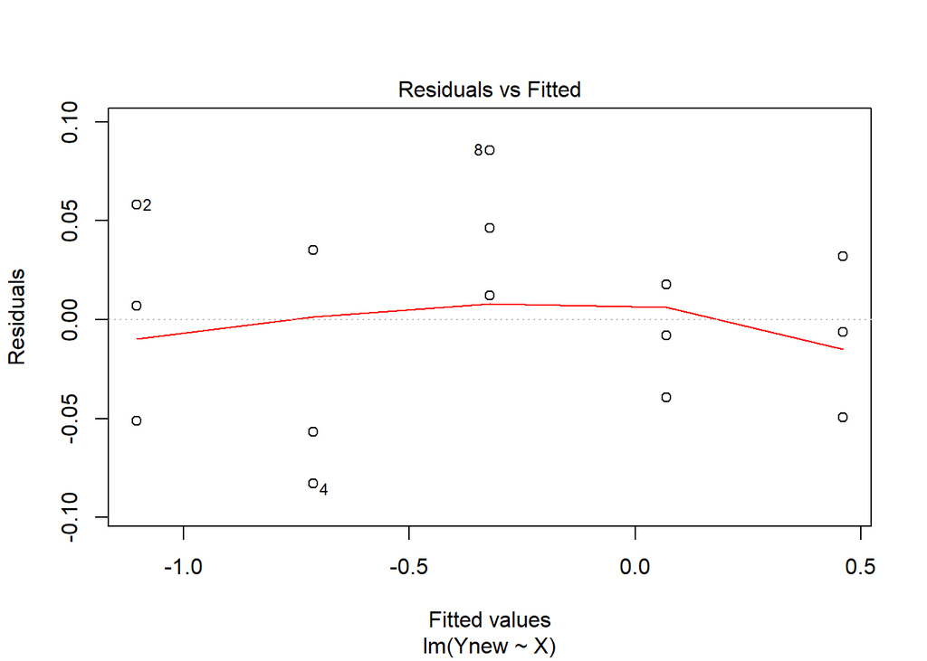

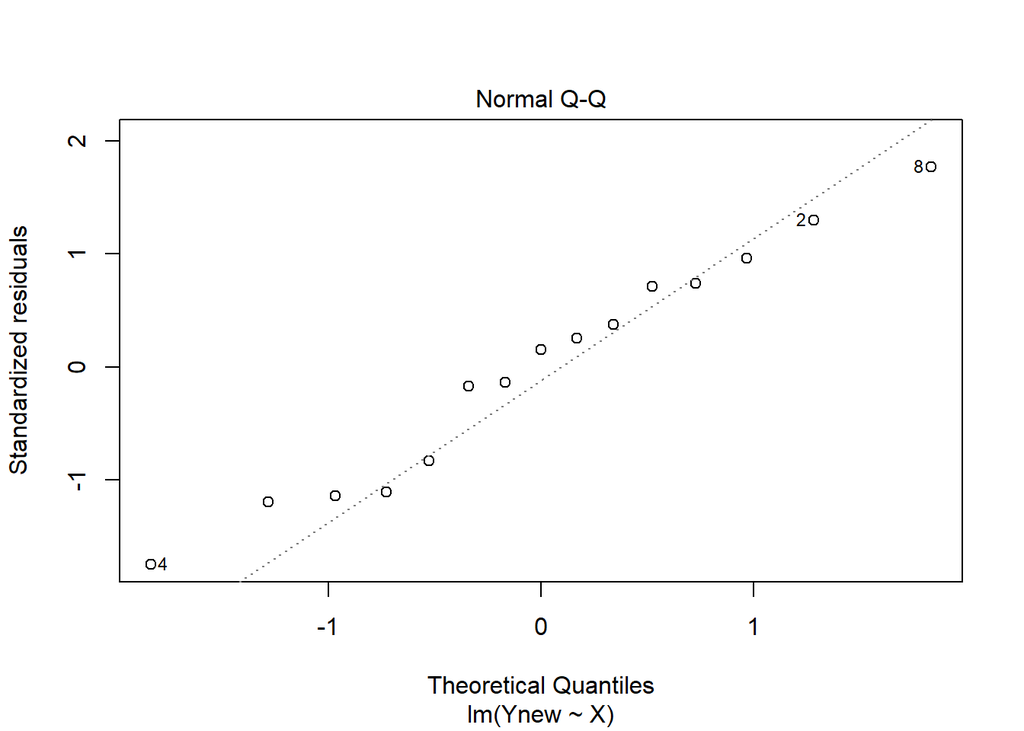

```r
plot(p3.15.lm, which = 1:2)
```

The residuals show that variance is relatively constant and is approximately normal.

6. Express the estimated regression function in the original units.

$\hat{Y}=10^{.655 -.1954X}$

### Problem 3.17 {6}{ / }

```r
# Load the Data:
p3.17 <- read.table("http://www.stat.ufl.edu/~rrandles/sta4210/Rclassnotes/data/textdatasets/KutnerData/Chapter%20%203%20Data%20Sets/CH03PR17.txt")

# Rewrite the column names to be "Y" and "X" to match the textbook:
colnames(p3.17) <- c("Y","X")
```

### Problem 3.18 {5}{ / }

```r
# Load the Data:
p3.18 <- read.table("http://www.stat.ufl.edu/~rrandles/sta4210/Rclassnotes/data/textdatasets/KutnerData/Chapter%20%203%20Data%20Sets/CH03PR18.txt")

# Rewrite the column names to be "Y" and "X" to match the textbook:
colnames(p3.18) <- c("Y","X")
```